# Data Science Specialization Capstone Project

Sergii Sorokolat  
8/22/2018

Next Word Prediction based on Ngram language model and Stupid Backoff Algorithm

### Executive summary

- The goal of the project is to build an algorithm that predicts the next word based on user's input (words, sentences, phrases)
- The predictive model was built using Ngram language model from Natural Language Processing
- The training data for the model is 30% random sample from the original dataset provided by SwiftKey
- The final data product was implemented as a Shiny App

### Language model

- The original dataset contains 4269678 lines of text (102080240 words) from Twitter, news and blogs
- Data cleansing stage included removing special characters, numbers, punctuation and profanity words
- The model utilizes the combination of 2-6 Ngrams built from the preprocessed dataset
- The app implements Stupid Backoff smoothing method introduced by Google

Reference: [Large Language Models in Machine Translation](https://www.aclweb.org/anthology/D07-1090.pdf)

### Algorithm

The algorithm is inexpensive to train on large data sets and approaches the quality of Kneser-Ney Smoothing as the amount of training data increases, so:

- It gives model good accuracy
- It requires fewer computer resources compared to other methods, e.g. Katz' Backoff Model

Scoring function:

\( S(w_i|w_{i-k+1}^{i-1}) = \Bigg\{\begin{align*} \frac{f(w_{i-k+1}^i)}{f(w_{i-k+1}^{i-1})} \quad if \quad f(w_{i-k+1}^i) > 0 \\ \alpha S(w_i|w_{i-k+2}^{i-1}) \quad\quad otherwise\end{align*} \)

Backoff factor \( \alpha \) was set to 0.4 based on Google recommendations.

### Data product

- The app is hosted on shinyapps.io and can be found here: https://datasalad.shinyapps.io/shinappdscapstone/
- The app is fairly simple to use. Just type in a few words or a sentence and hit 'Predict'. The suggested next word will show up.

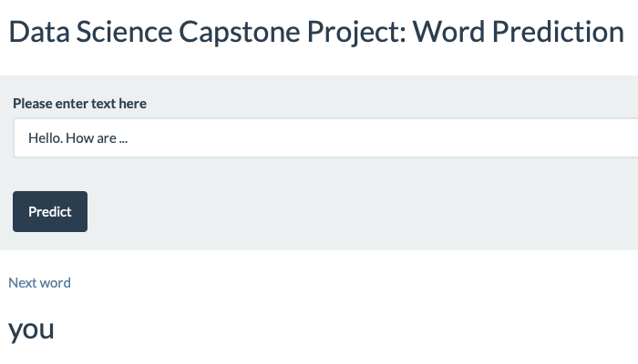

Thanks for your time!